| Bradley Brook Reservoir | Hatch-Bradley Brook Lakes Association | Town(s) of West Eaton | Madison County |
| --- | --- | --- | --- |

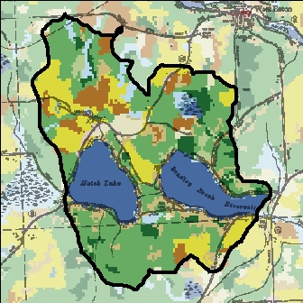

## Bradley Brook Reservoir – 2018 Sampling Season Results

Open Water Indicators

2018 Sampling Results

Seasonal Change

Season Avg

Decadal Average

Decadal Trend?

Longterm Avg

Longterm Trend?

06-03

06-16

07-01

07-15

07-28

08-12

08-26

09-06

Clarity (m)

6.3

7.3

7.2

6.4

5.5

3.5

2.8

2.9

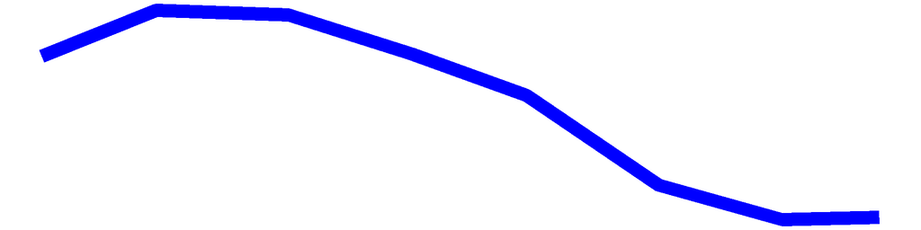

5.8

6.5

5.3

Surface TP (mg/L)

0.007

0.008

0.008

0.008

0.011

0.012

0.019

0.016

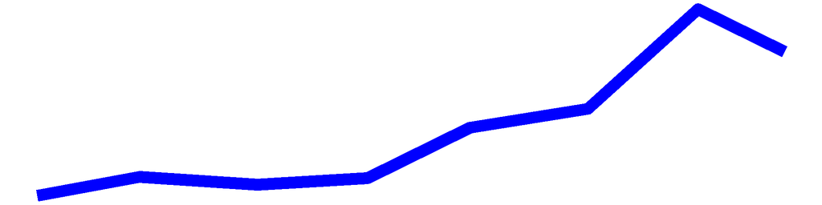

0.01

0.01

0.011

Surface TDP (mg/L)

0.004

0.004

0.004

0.007

0.004

0.008

0.011

0.008

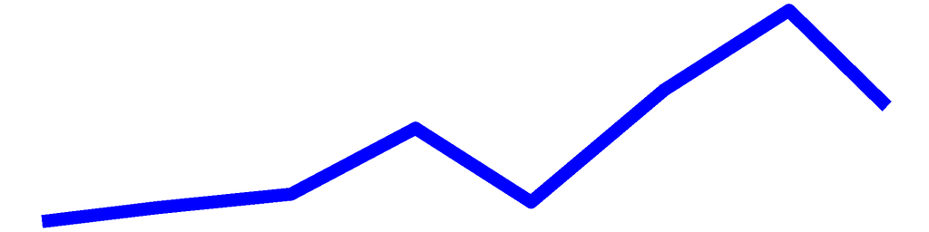

0.006

Deep TP (mg/L)

0.008

0.007

0.007

0.007

0.008

0.014

0.019

0.028

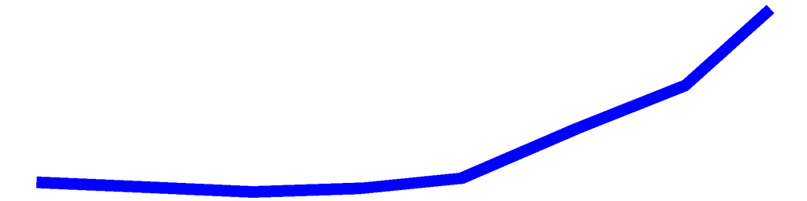

0.012

0.01

0.012

Deep TDP (mg/L)

0.005

0.005

0.005

0.005

0.007

0.01

0.006

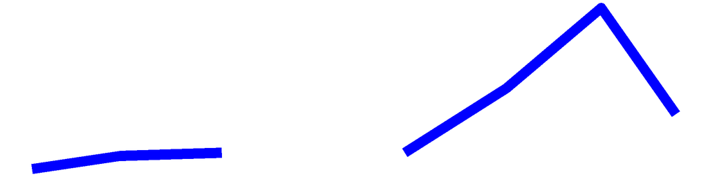

0.006

TN (mg/L)

0.624

0.461

0.477

0.462

0.39

0.416

0.372

0.426

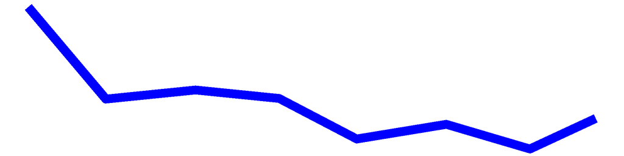

0.453

0.287

0.287

TDN (mg/L)

0.597

0.446

0.48

0.445

0.401

0.389

0.432

0.393

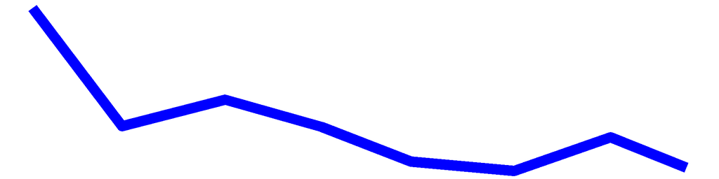

0.448

0.248

0.248

TN:TP

90

57

63

58

35

34

20

27

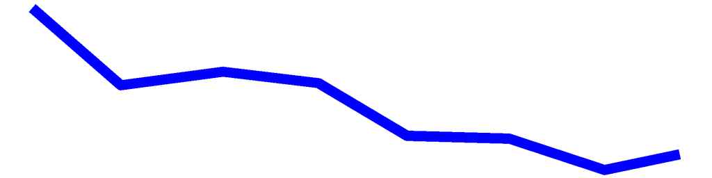

48

30

30

Surface NH3 (mg/L)

0.034

0.076

0.045

0.032

0.005

0.005

0.018

0.013

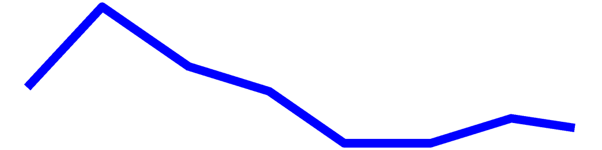

0.028

0.025

0.025

Deep NH3 (mg/L)

0.037

0.043

0.076

0.034

0.005

0.093

0.01

0.011

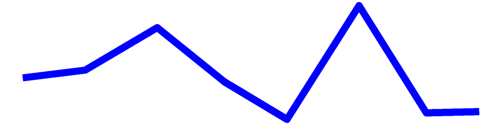

0.039

0.041

0.041

Chl.a (ug/L)

1.1

1.1

1.3

2.4

3.1

4.1

6.2

5.6

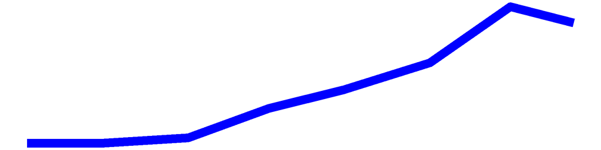

2.7

1.7

3.3

pH

7.4

7.4

7.4

7.6

7.2

7.2

6.8

7

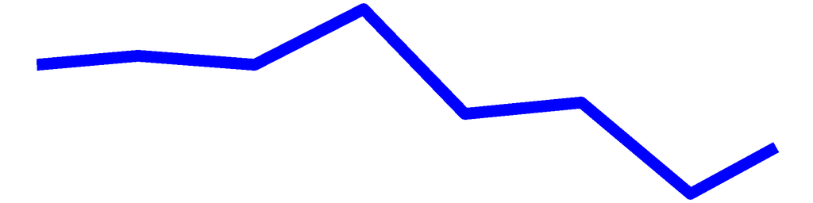

7.2

7.4

7.9

Cond (umho/cm)

181

190

238

241

204

202

130

146

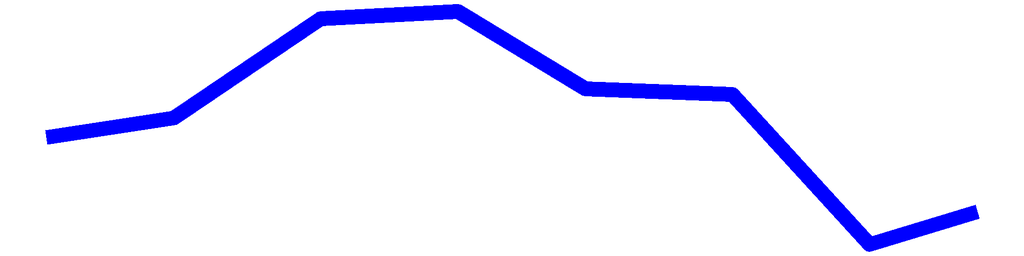

191

196

200

Surface Chloride (mg/L)

18

14

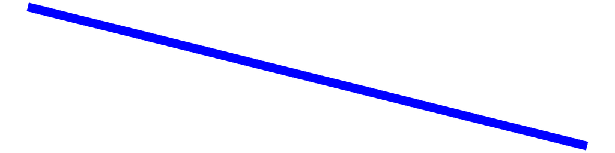

16

27

27

Upper Temp (degC)

21

19

24

26

24

25

24

26

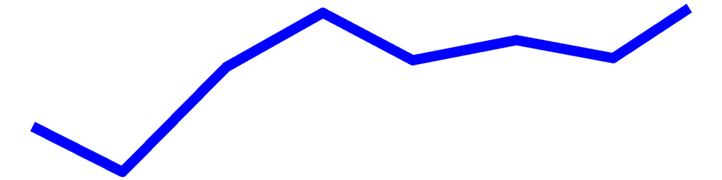

24

23

23

Deep Temp (degC)

16

19

24

25

26

24

25

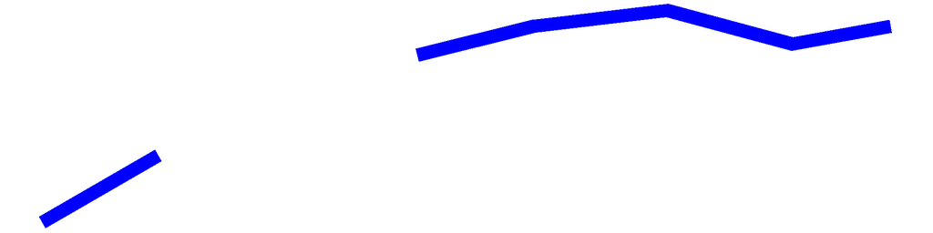

23

22

22

FP BG Chl.a (ug/L)

0.1

0.1

0.4

0.3

0.1

0

0.5

1.2

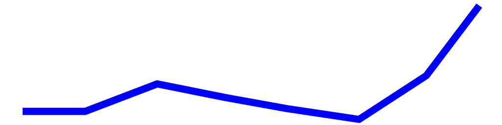

0.3

0.3

0.3

### NYHABs notifications

#### Were there any reported HABs this season? **Yes.**

| Date of First Listing | Date of Last Listing | Number of Reports |
| --- | --- | --- |
| 09/14/2018 | 09/14/2018 | 7 |

### Shoreline HAB Sample Dates 2018

| HAB Indicators | Criteria | 09-14 |
| --- | --- | --- |
| FP BGA Chl. a | 25 ug/L | 919.5 |
| Microcystin | 20 ug/L | 7.1 |
| Microscopy | Dominant | Dolichospermum, Woronchinia, Anabaena |

### HABs Status

#### Open Water Algae

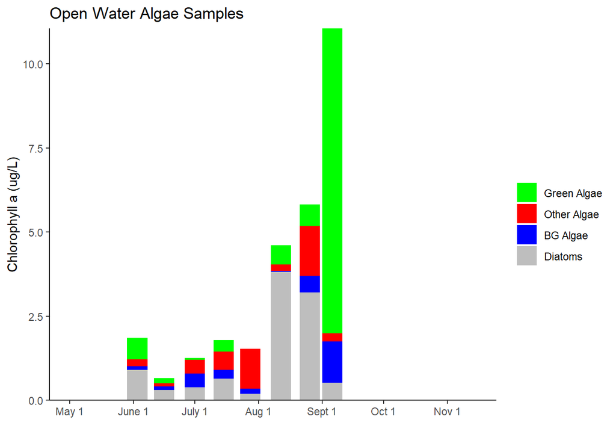

#### Shoreline Algae

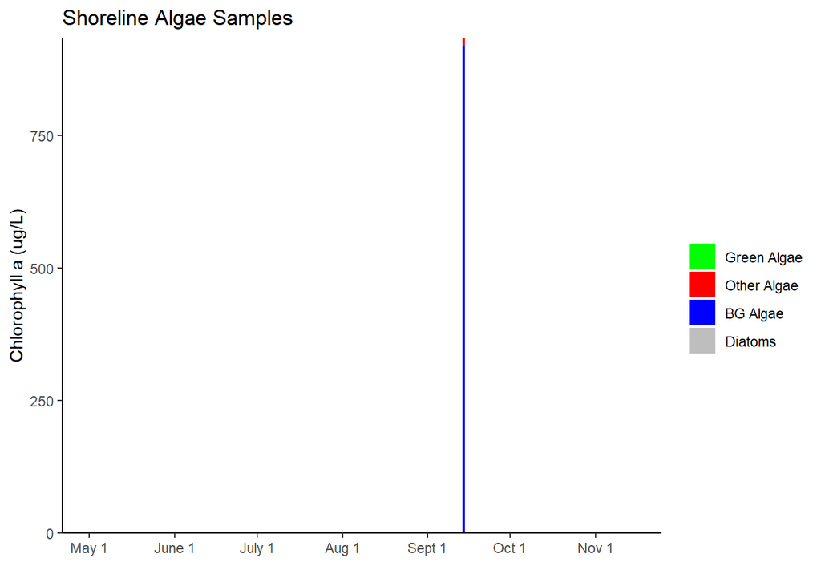

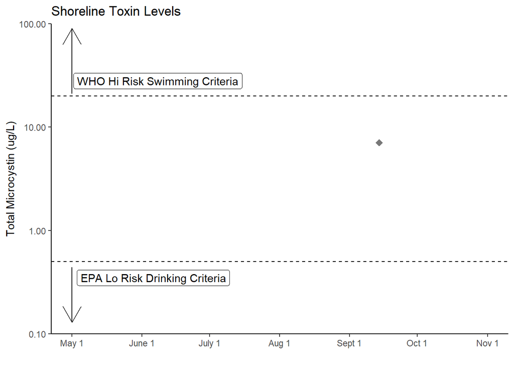

## Bradley Brook Reservoir Long-Term Trend Analysis

#### Clarity

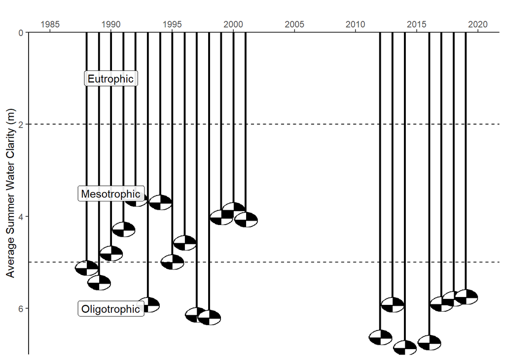

#### Chlorophyll *a*

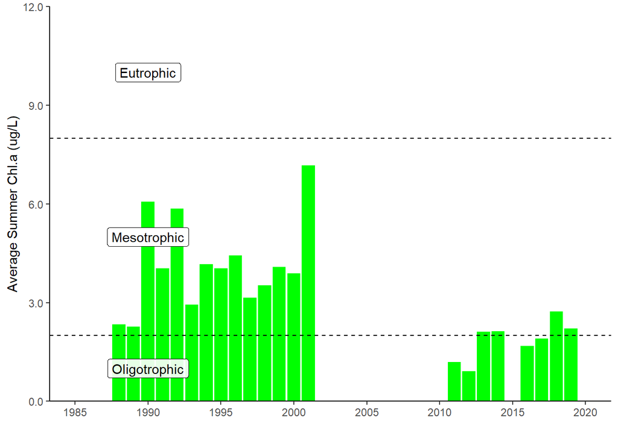

#### Surface and Deep Phosphorus

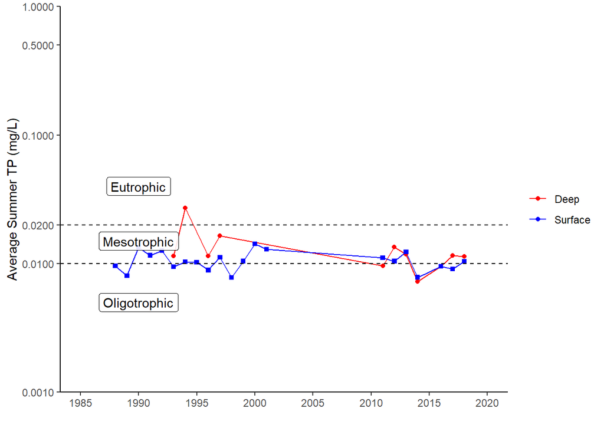

#### Nitrogen

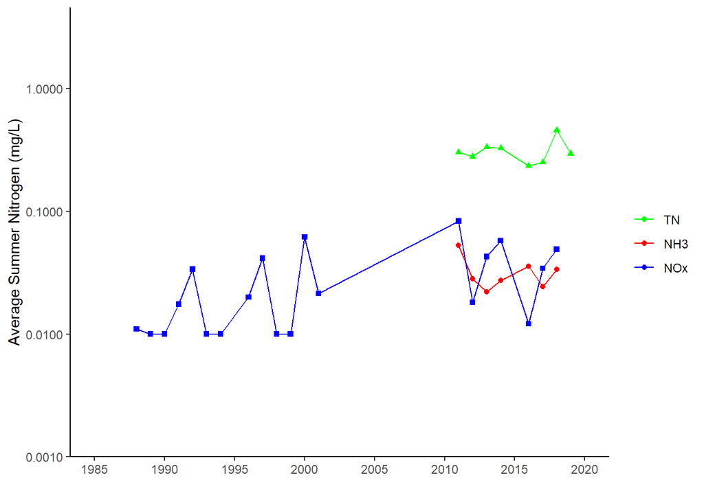

#### TN : TP

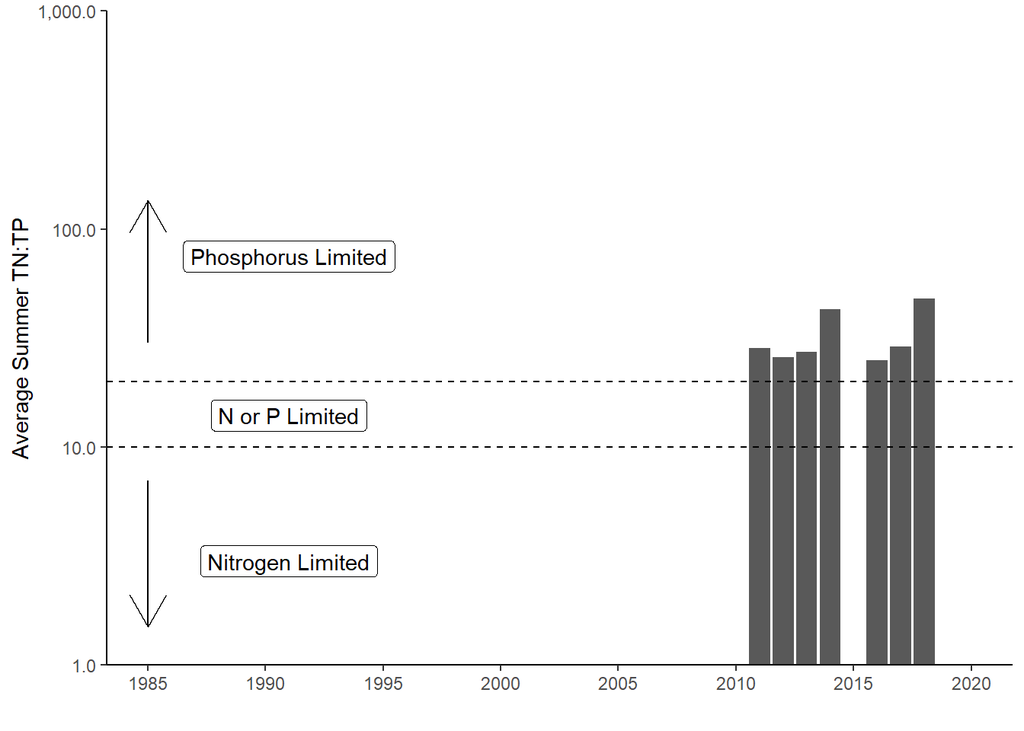

#### pH

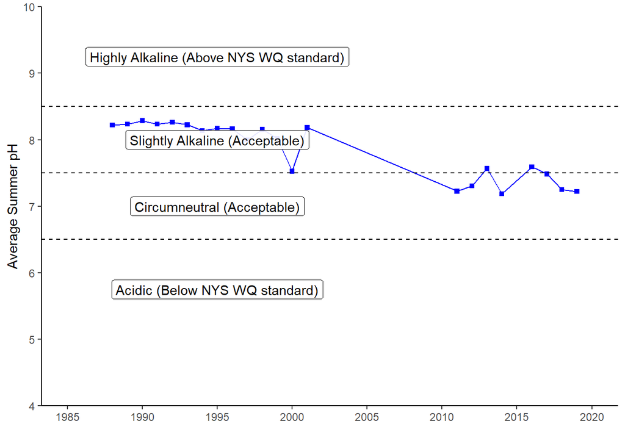

#### Specific Conductance

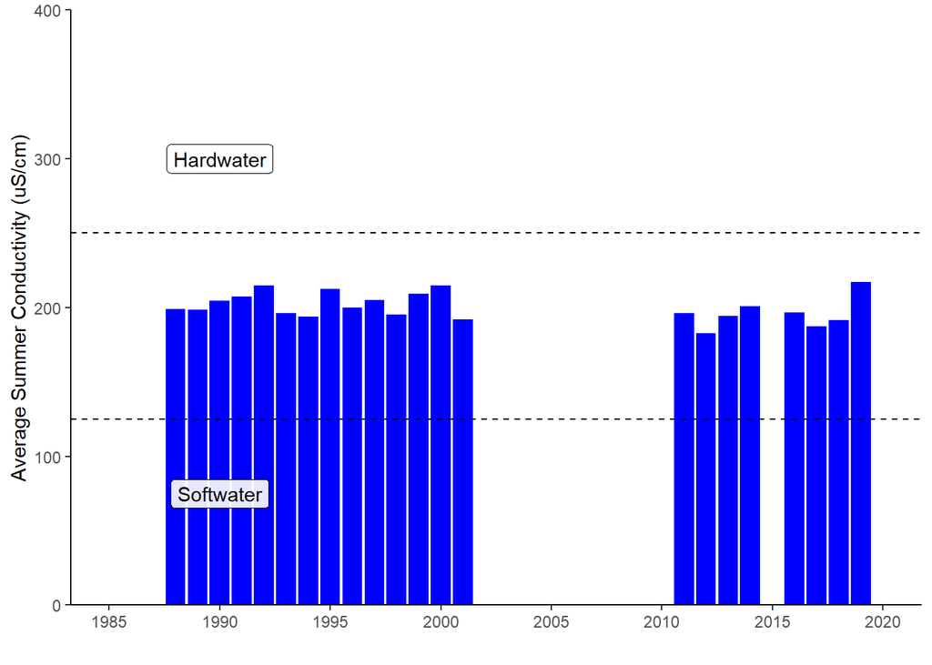

#### Calcium

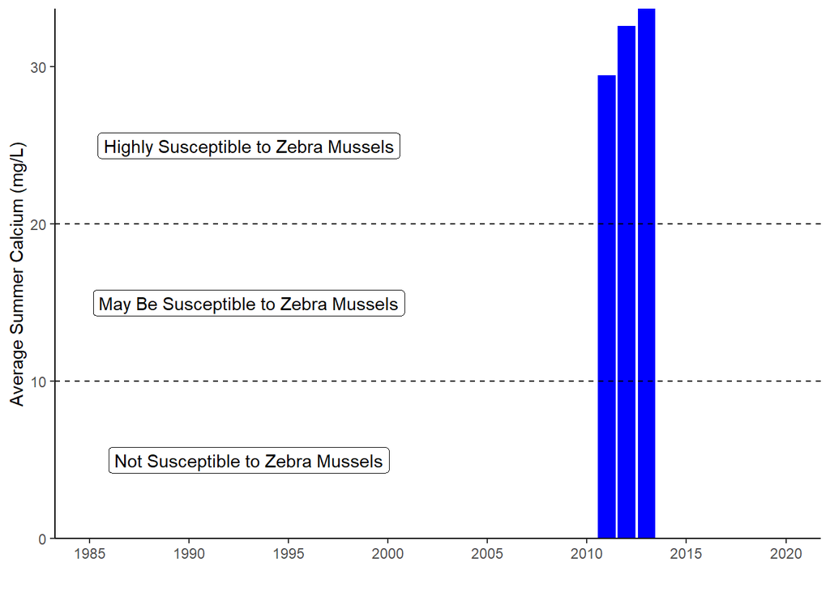

#### Chloride

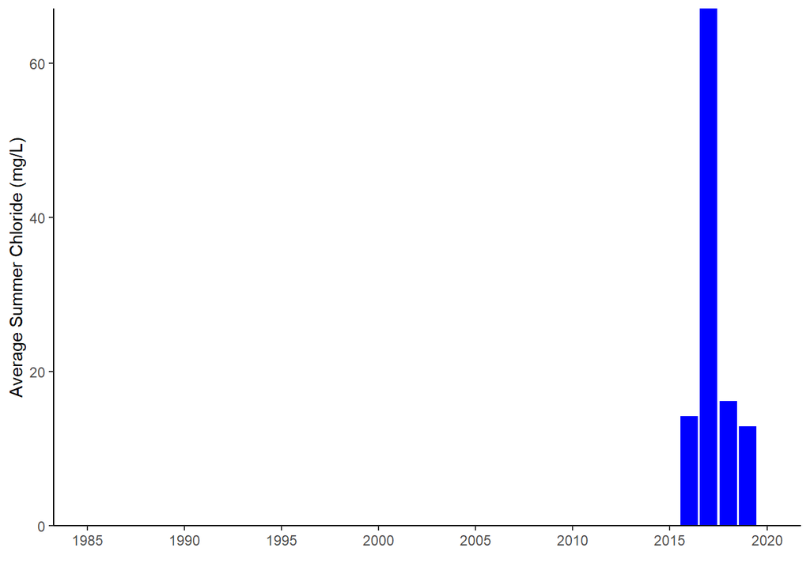

#### Color

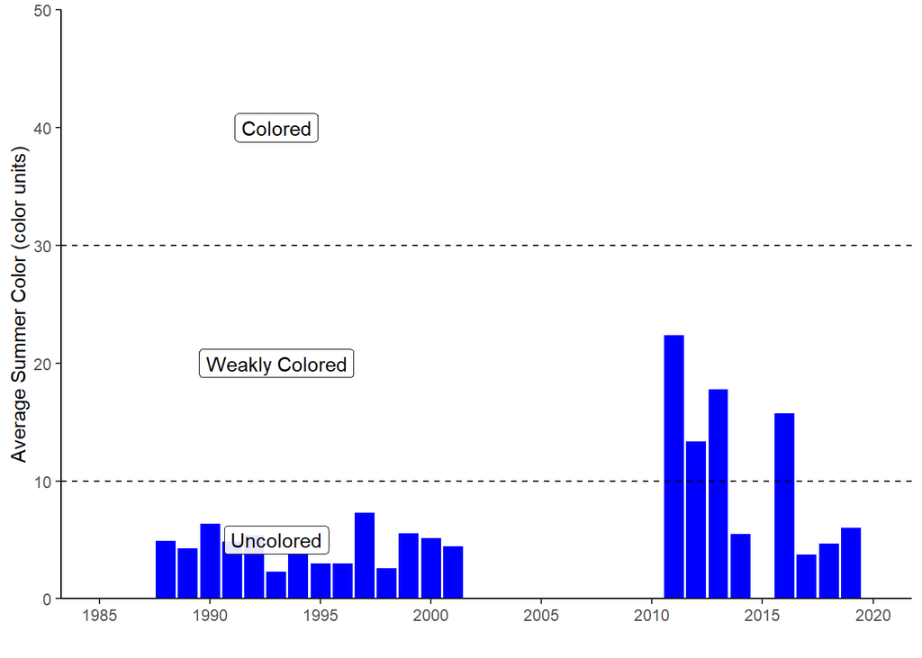